# Do Preventive Financial Behaviors Improve Financial Resilience?

## Finding the Best Predictive Model: Lasso Regression

So far, we tested how well our model predicts financial resilience. But we can ask a bigger question: what is the best model we can possibly build? To answer this, we use Lasso regression with many more variables. The Lasso will automatically pick the most useful ones and remove the rest.

To build the Lasso model, we extend our analysis by including a wider set of variables. In addition to the main variables, we include demographic characteristics such as gender, age, education, and income level. We also add variables related to financial inclusion, such as having an account, saving behavior, and borrowing behavior.

Moreover, for the Lasso model, we include more detailed indicators of financial activity. For example, we consider formal savings (fin17a), savings through mobile money (fin17b), borrowing from financial institutions (fin22a), and borrowing from family or friends (fin22b). These variables help capture different ways households manage their finances.

In addition, we include variables related to access to technology and connectivity, such as internet use and mobile phone ownership. We also control for employment status and whether the household lives in a rural or urban area. Finally, we include the region variable to capture broader economic and institutional differences across countries .

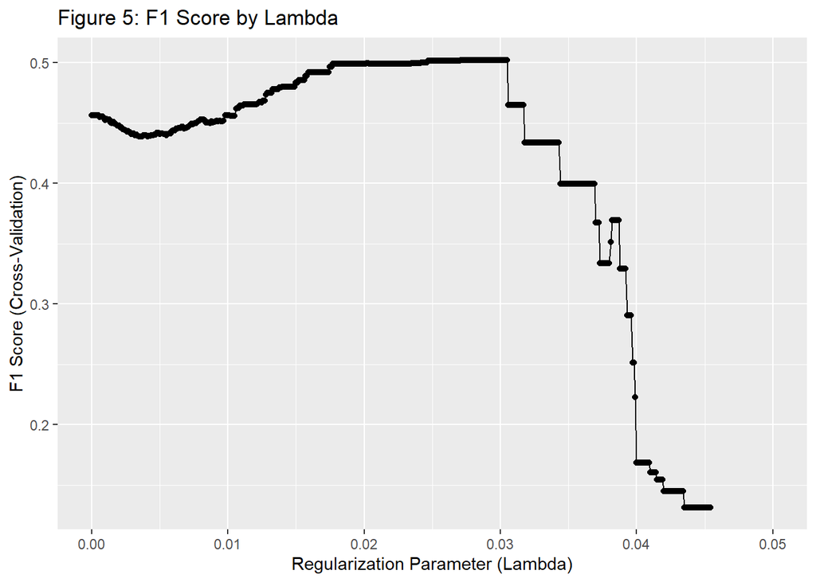

```r
# Convert fin24b_binary to factor in the original dataset BEFORE filtering
dataset <- dataset %>%
  mutate(fin24b_binary = factor(
    fin24b_binary,
    levels = c(0, 1),
    labels = c("Not_Resilient", "Resilient")
  ))

# Now filter for lasso dataset
dataset_lasso <- dataset %>%
  filter(
    !is.na(fin24b_binary),
    !is.na(preventive_risk_index),
    !is.na(female),
    !is.na(age),
    !is.na(educ),
    !is.na(inc_q),
    !is.na(urbanicity),
    !is.na(account),
    !is.na(saved),
    !is.na(borrowed),
    !is.na(fin17a),
    !is.na(fin17b),
    !is.na(fin22a),
    !is.na(fin22b),
    !is.na(internet_use),
    !is.na(con1),
    !is.na(emp_in),
    !is.na(regionwb)
  ) %>%
  mutate(
    female       = as.factor(female),
    account      = as.factor(account),
    saved        = as.factor(saved),
    borrowed     = as.factor(borrowed),
    fin17a       = as.factor(fin17a),
    fin17b       = as.factor(fin17b),
    fin22a       = as.factor(fin22a),
    fin22b       = as.factor(fin22b),
    internet_use = as.factor(internet_use),
    con1         = as.factor(con1),
    emp_in       = as.factor(emp_in)
  )

# Define training control
train_control_lasso <- trainControl(method = "cv",
                                    number = 10,
                                    classProbs = TRUE,
                                    summaryFunction = prSummary)

# Lasso logistic regression
m_lasso <- train(fin24b_binary ~ preventive_risk_index + female + age + educ +
                   inc_q + urbanicity + account + saved + borrowed +
                   fin17a + fin17b + fin22a + fin22b +
                   internet_use + con1 + emp_in + regionwb,
                 data = dataset_lasso,
                 method = "glmnet",
                 family = "binomial",
                 tuneGrid = expand.grid(alpha = 1,
                                        lambda = seq(0, 0.05, 0.0001)),
                 metric = "F",
                 trControl = train_control_lasso)

# Plot
ggplot(m_lasso, metric = "F") +
  labs(title = "Figure 5: F1 Score by Lambda",
       x = "Regularization Parameter (Lambda)",
       y = "F1 Score (Cross-Validation)")
```

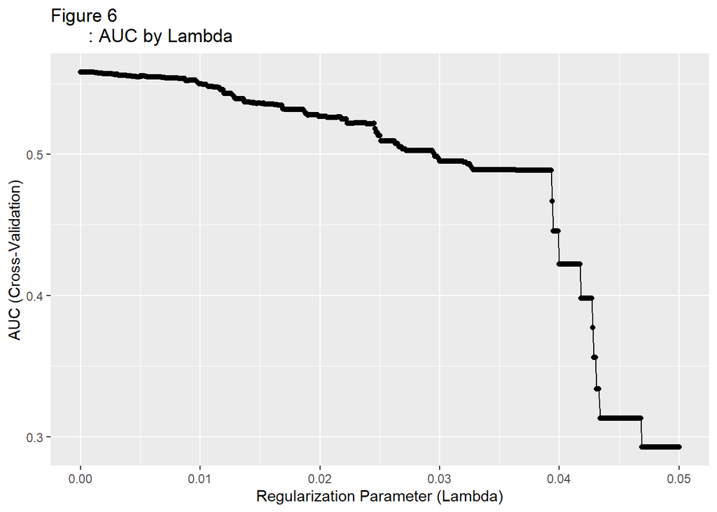

```r
ggplot(m_lasso, metric = "AUC") +
  labs(title = "Figure 6
       : AUC by Lambda",
       x = "Regularization Parameter (Lambda)",
       y = "AUC (Cross-Validation)")
```

```r
library(knitr)
# Results for the best model
table <- m_lasso$results[which(m_lasso$results$lambda == m_lasso$bestTune$lambda), ]
kable(
  table,
  caption = "Table 10: Performance of the Best Lasso Model (Optimal Lambda)"
)
```

Table 10: Performance of the Best Lasso Model (Optimal Lambda)

|  | alpha | lambda | AUC | Precision | Recall | F | AUCSD | PrecisionSD | RecallSD | FSD |
| --- | --- | --- | --- | --- | --- | --- | --- | --- | --- | --- |
| 306 | 1 | 0.0305 | 0.4949244 | 0.5475549 | 0.4641988 | 0.5022301 | 0.0151764 | 0.0171287 | 0.0141987 | 0.0106958 |

```r
library(knitr)

# Extract coefficients
lasso_coef <- as.matrix(coef(m_lasso$finalModel, m_lasso$bestTune$lambda))

# Keep only non-zero coefficients
lasso_coef_df <- data.frame(
  Variable = rownames(lasso_coef),
  Coefficient = round(lasso_coef[, 1], 6)
) %>%
  filter(Coefficient != 0)

# Display with kable
kable(lasso_coef_df,
      caption = "Table11: Non-zero coefficients from the Lasso model",
      row.names = FALSE)
```

Table11: Non-zero coefficients from the Lasso model

| Variable | Coefficient |
| --- | --- |
| (Intercept) | -0.016104 |
| internet_use1 | -0.002041 |
| regionwbSouth Asia | -0.122838 |
| regionwbSub-Saharan Africa (excluding high income) | 0.231297 |

In contrast, all other variables, including the preventive risk index, age, income, and financial behavior indicators, are shrunk to zero. This means that they do not contribute to the final prediction of the model.

Overall, the predictive modelling section shows that financial resilience is hard to predict. Our base model with two variables performed poorly, and even the Lasso with many more variables did not improve much. The most important finding is that geography, particularly the region where a household lives, matters more than individual financial behaviors for predicting resilience. This suggests that structural and contextual factors play a bigger role than individual preventive behaviors.

## Conclusion

This paper examined whether preventive financial behaviors help households become more resilient to income shocks. Overall, the results support our initial hypothesis. We consistently find a positive relationship between preventive behaviors and financial resilience. Households that save or have insurance tend to be slightly more able to cope with financial shocks.

This result remains stable across different models and specifications. The sensitivity analyses confirm that the effect is always positive, even when we change the model or use different versions of the data. This strengthens the validity of our main finding.

However, the effect remains relatively small. In addition, the predictive models perform poorly. Even the best models have low accuracy and low F1 scores. This shows that financial resilience is difficult to predict and depends on many factors.

One important limitation is that our measure of financial resilience is quite simple. It is based only on how long households can cover their expenses, which does not capture all aspects of financial stability. Another limitation is that our preventive risk index includes only savings and insurance, while other forms of financial preparation are not considered.

In addition, the data used in this study is cross-sectional. This means that we observe households at one point in time. As a result, we cannot fully capture how financial behaviors affect resilience over time. Using longitudinal data would be more appropriate, as it would allow us to track households and better understand how preventive behaviors influence resilience before and after shocks.

For these reasons, future research could therefore use longitudinal data and include more detailed measures of financial behavior. It could also explore the role of regional and institutional factors more deeply.